# Análisis de Sentimiento usando Música Popular via Python

# 4 Visualice el gráfico de wordcloud

- Obtenemos algunas ideas clave: la palabra: **libertad**
- **libertad** se destaca en comparación con otras palabras en el discurso de Martin Luther King Junior en su pronunciamento de **I have a dream**.

```r
findFreqTerms(dream.corpus.clean %>%
                tm::TermDocumentMatrix(), lowfreq = 4)
```

```
##  [1] "able"     "day"      "dream"    "every"    "faith"    "freedom"
##  [7] "mountain" "nation"   "one"      "shall"    "together"
```

**Asociación entre términos frecuentes**

```r
findAssocs(dream.corpus.clean %>%
             tm::TermDocumentMatrix(), terms = "freedom", corlimit = 0.3)
```

```
## $freedom
## numeric(0)
```

**La tabla de frecuencia de las palabras**

```r
head(dream.corpus.clean.tb, 10)
```

|  | word | freq |
| --- | --- | --- |
| 1 | freedom | 12 |
| 2 | day | 10 |
| 3 | every | 9 |
| 4 | able | 8 |
| 5 | dream | 8 |
| 6 | one | 7 |
| 7 | together | 6 |
| 8 | faith | 4 |
| 9 | mountain | 4 |
| 10 | nation | 4 |

**Graficar las palabras según du frecuencia**

- La tabla de frecuencia de las primeras 10 palabras son graficadas:

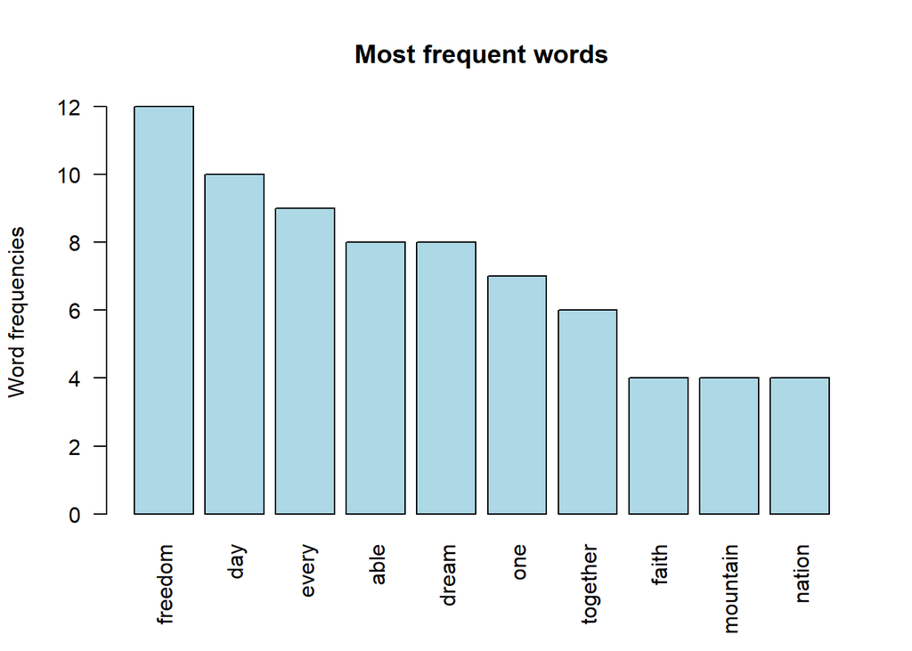

```r
barplot(dream.corpus.clean.tb[1:10,]$freq, las = 2, names.arg = dream.corpus.clean.tb[1:10,]$word,
        col ="lightblue", main ="Most frequent words",
        ylab = "Word frequencies")
```

# 5 **Análisis de Sentimiento**

- El paquete clave es **tidytext** selecciona las palabras asociadas a **sentimientos** positivos y negativos.

```r
require(rlang)
require(tidytext)
require(tidyr)
require(dplyr)

library(textdata)
library(tidytext) # get_sentiments
library(reshape2) # acast
library(wordcloud) # comparison.cloud
```

**Sintaxis usando la función *inner_join(get_sentiments(“bing”))***

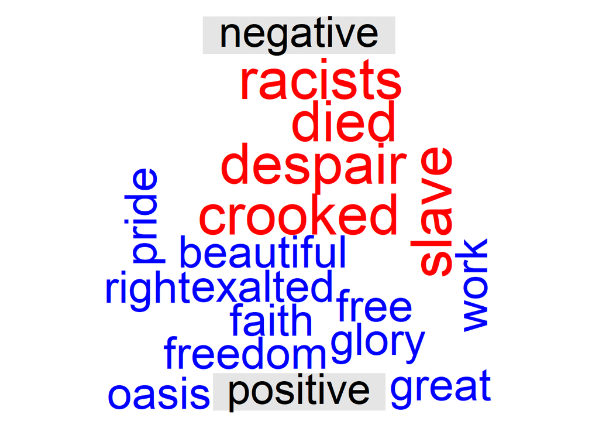

```r
dream.corpus.clean.tb %>%
  inner_join(get_sentiments("bing")) %>%
  count(word, sentiment, sort = TRUE) %>%
  acast(word ~ sentiment, value.var = "n", fill = 0) %>%
  comparison.cloud(colors = c("red", "blue"),
                   max.words = 1000)
```

# 6 Ejemplo Maluma y sus músicas.

- name <- “maluma.txt”
- name <- “4babys.txt”
- name <- “borro cassette.txt”
- name <- “chantaje.txt”
- name <- “el perdedor.txt”
- name <- “Felices los 4.txt”
- name <- “la temperatura.txt”
- name <- “sin contrato.txt”

Librerias necesitadas

```r
library(RXKCD)
library(tm)
library(wordcloud)
library(RColorBrewer)
```

** Felices los 4 **

```r
name = "Felices los 4.txt"
```

- Lectura de los datos

```r
txt <- readLines(paste("C:/Users/pchir/Google Drive/TextMining/Music_Sentimentalanalysis/Maluma_original/Code_maluma/",name,sep = ""),encoding="UTF-8")
txt = iconv(txt, to="ASCII//TRANSLIT")
sw <- readLines(paste("C:/Users/pchir/Google Drive/TextMining/Music_Sentimentalanalysis/Maluma_original/Code_maluma/",name,sep = ""),encoding="UTF-8")
sw = iconv(txt, to="ASCII//TRANSLIT")
```

- Construyendo la matriz de palabras

```r
# txt <- readLines("C:/Users/pchir/Google Drive/TextMining/Music_Sentimentalanalysis/Maluma_original/Code_maluma/chantaje.txt",encoding="UTF-8")
# txt = iconv(txt, to="ASCII//TRANSLIT")

# sw <- readLines("C:/Users/pchir/Google Drive/TextMining/Music_Sentimentalanalysis/Maluma_original/Code_maluma/chantaje.txt",encoding="UTF-8")
# sw = iconv(sw, to="ASCII//TRANSLIT")

require(tm) ## Corpus

corpus <- Corpus(VectorSource(txt))
d  <- tm_map(corpus, tolower)
d  <- tm_map(d, stripWhitespace)
d <- tm_map(d, removePunctuation)

d <- tm_map(d, removeWords, stopwords("spanish"))
d <- tm_map(d, removeWords, sw)
tdm <- TermDocumentMatrix(d)
findFreqTerms(tdm, lowfreq=2)
```

```
##  [1] "baby"       "maluma"     "vas"        "asi"        "conmigo"
##  [6] "quedas"     "carajo"     "importa"    "volveras"   "pasas"
## [11] "rato"       "feliz"      "ser"        "vamos"      "felices"
## [16] "agrandamos" "cuarto"     "acepto"     "trato"      "hacemos"
## [21] "boom"       "regresa"    "siempre"    "diran"      "gusta"
## [26] "tal"
```

- Creando la nube

```r
m <- as.matrix(tdm)
v <- sort(rowSums(m),decreasing=TRUE)
d <- data.frame(word = names(v),freq=v)
pal <- brewer.pal(9, "BuGn")
pal <- pal[-(1:2)]
```

- Creando la nube formato aleatório con función *wordcloud*

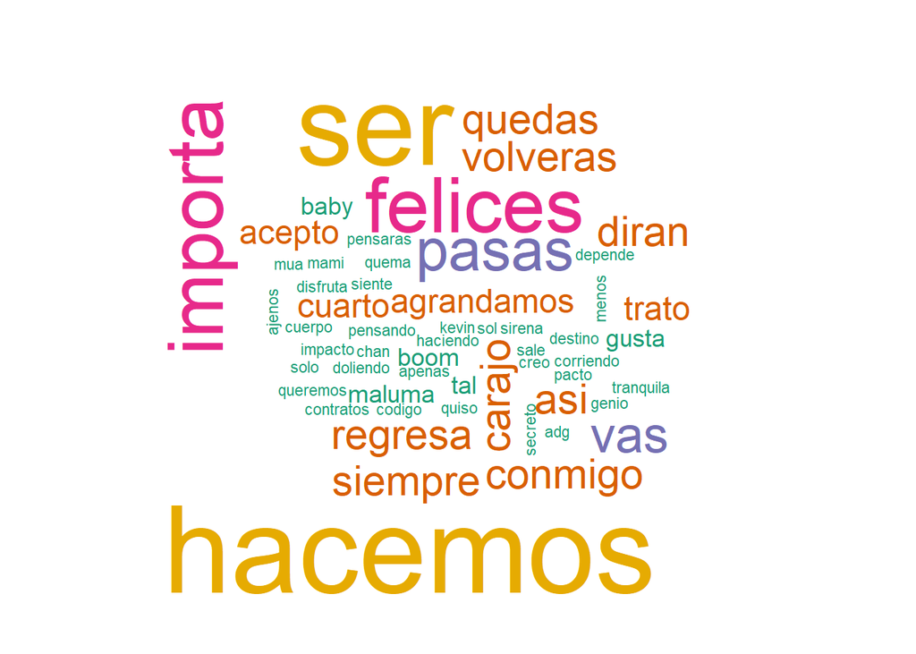

```r
wordcloud(d$word,d$freq, scale=c(8,.3),
          min.freq=1,max.words=200, random.order=TRUE,
          rot.per=.15, colors=brewer.pal(20, "Dark2"))
```

** Chantaje **

```r
library(RXKCD)
library(tm)
library(wordcloud)
library(wordcloud2)
library(RColorBrewer)

name = "chantaje.txt"

txt <- readLines(paste("C:/Users/pchir/Google Drive/TextMining/Music_Sentimentalanalysis/Maluma_original/Code_maluma/",name,sep = ""),encoding="UTF-8")
txt = iconv(txt, to="ASCII//TRANSLIT")
sw <- readLines(paste("C:/Users/pchir/Google Drive/TextMining/Music_Sentimentalanalysis/Maluma_original/Code_maluma/",name,sep = ""),encoding="UTF-8")
sw = iconv(txt, to="ASCII//TRANSLIT")

require(tm) ## Corpus

corpus <- Corpus(VectorSource(txt))
d  <- tm_map(corpus, tolower)
d  <- tm_map(d, stripWhitespace)
d <- tm_map(d, removePunctuation)

d <- tm_map(d, removeWords, stopwords("spanish"))
d <- tm_map(d, removeWords, sw)
tdm <- TermDocumentMatrix(d)
findFreqTerms(tdm, lowfreq=2)
```

```
##  [1] "bien"       "ahi"        "siempre"    "dame"       "baby"
##  [6] "mala"       "preguntale" "quieras"    "asi"        "juro"
## [11] "vida"       "intencion"  "nunca"      "burlarme"   "quise"
## [16] "conmigo"    "sabe"       "ves"        "dia"        "digo"
## [21] "masoquista" "cuerpo"     "egoista"    "chantaje"   "puro"
## [26] "manera"     "aunque"     "quiera"     "quiero"     "aire"
## [31] "libre"      "vas"        "nadie"      "eheheh"     "alright"
```

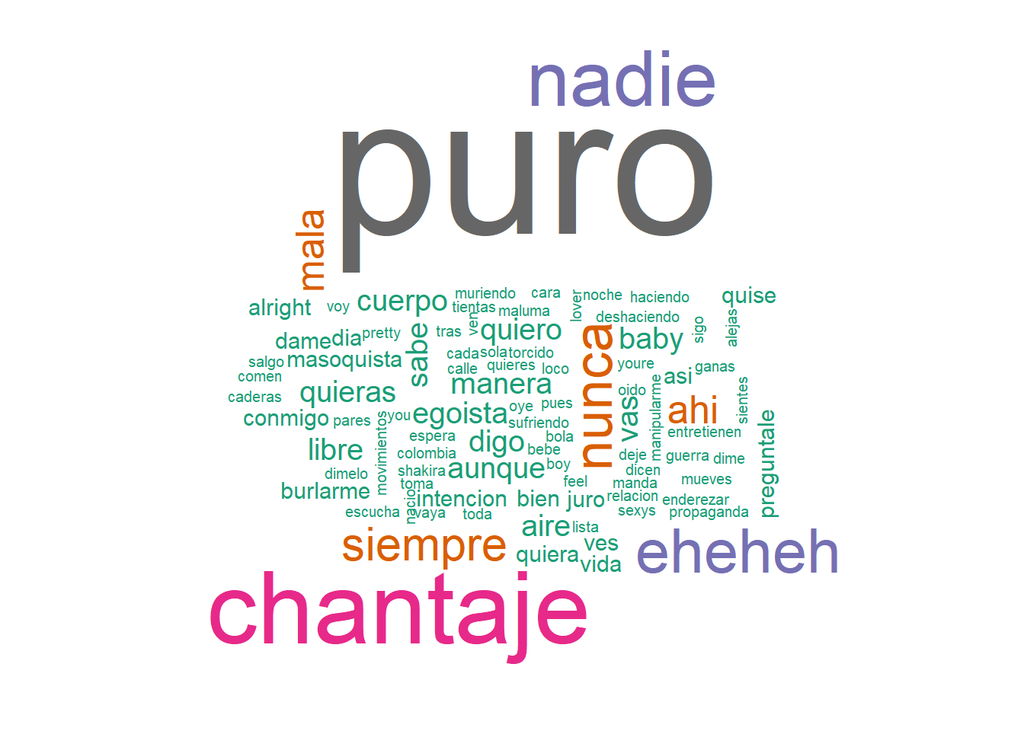

```r
m <- as.matrix(tdm)
v <- sort(rowSums(m),decreasing=TRUE)
d <- data.frame(word = names(v),freq=v)
pal <- brewer.pal(9, "BuGn")
pal <- pal[-(1:2)]


wordcloud(d$word,d$freq, scale=c(8,.3),
          min.freq=1,max.words=200, random.order=TRUE,
          rot.per=.15, colors=brewer.pal(11, "Dark2"))
```

** Borro Cassette **

```r
library(RXKCD)
library(tm)
library(wordcloud)
library(wordcloud2)
library(RColorBrewer)

name = "borro cassette.txt"

txt <- readLines(paste("C:/Users/pchir/Google Drive/TextMining/Music_Sentimentalanalysis/Maluma_original/Code_maluma/",name,sep = ""),encoding="UTF-8")
txt = iconv(txt, to="ASCII//TRANSLIT")
sw <- readLines(paste("C:/Users/pchir/Google Drive/TextMining/Music_Sentimentalanalysis/Maluma_original/Code_maluma/",name,sep = ""),encoding="UTF-8")
sw = iconv(txt, to="ASCII//TRANSLIT")

require(tm) ## Corpus

corpus <- Corpus(VectorSource(txt))
d  <- tm_map(corpus, tolower)
d  <- tm_map(d, stripWhitespace)
d <- tm_map(d, removePunctuation)

d <- tm_map(d, removeWords, stopwords("spanish"))
d <- tm_map(d, removeWords, sw)
tdm <- TermDocumentMatrix(d)
findFreqTerms(tdm, lowfreq=2)
```

```
##  [1] "ayer"       "besaste"    "parar"      "podias"     "amanecer"
##  [6] "bailaste"   "desperte"   "llamar"     "quise"      "ahora"
## [11] "borro"      "cassette"   "dice"       "acuerda"    "noche"
## [16] "conoce"     "quiero"     "ver"        "volverla"   "cabeza"
## [21] "estragos"   "hicieron"   "tragos"     "besa"       "cualquiera"
## [26] "interesa"   "sepa"       "belleza"    "dia"        "pare"
## [31] "pensar"     "mami"       "pasa"       "tranquila"  "acuerdas"
## [36] "dices"      "calienta"   "cara"       "dimelo"     "mientas"
## [41] "ven"        "dejemos"    "jugar"      "cuerpo"     "bien"
## [46] "hicimos"    "yeah"       "boy"        "baby"
```

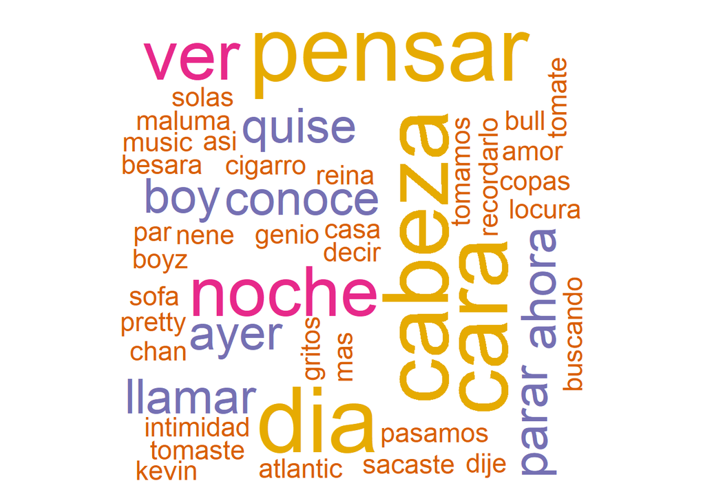

```r
m <- as.matrix(tdm)
v <- sort(rowSums(m),decreasing=TRUE)
d <- data.frame(word = names(v),freq=v)
pal <- brewer.pal(9, "BuGn")
pal <- pal[-(1:2)]


wordcloud(d$word,d$freq, scale=c(8,.3),
          min.freq=1,max.words=200, random.order=TRUE,
          rot.per=.15, colors=brewer.pal(11, "Dark2"))
```

#References

- Bache, Stefan Milton, and Hadley Wickham. 2014. Magrittr: A Forward-Pipe Operator for R. https://CRAN.R-project.org/package=magrittr.
- Feinerer, Ingo, Kurt Hornik, and David Meyer. 2008. “Text Mining Infrastructure in R.” Journal of Statistical Software 25 (5): 1-54. http://www.jstatsoft.org/v25/i05/.
- Fellows, Ian. 2018. Wordcloud: Word Clouds. https://CRAN.R-project.org/package=wordcloud. Müller, Kirill, and Hadley Wickham. 2018. Tibble: Simple Data Frames. https://CRAN.R-project.org/package=tibble.